# Лабораторная работа №14

Операционные системы

Верниковская Е. А., НПИбд-01-23

Российский университет дружбы народов, Москва, Россия

10 мая 2024

# Вводная часть

## Цель работы

Изучить основы программирования в оболочке ОС UNIX. Научиться писать более сложные командные файлы с использованием логических управляющих конструкций и циклов.

## Задание

1. Написать командный файл, реализующий упрощённый механизм семафоров. Командный файл должен в течение некоторого времени t1 дожидаться освобождения ресурса, выдавая об этом сообщение, а дождавшись его освобождения, использовать его в течение некоторого времени t2<>t1, также выдавая информацию о том, что ресурс используется соответствующим командным файлом (процессом). Запустить командный файл в одном виртуальном терминале в фоновом режиме, перенаправив его вывод в другой (> /dev/tty#, где # — номер терминала куда перенаправляется вывод), в котором также запущен этот файл, но не фоновом, а в привилегированном режиме. Доработать программу так, чтобы имелась возможность взаимодействия трёх и более процессов.

## Задание

2. Реализовать команду man с помощью командного файла. Изучите содержимое каталога /usr/share/man/man1. В нем находятся архивы текстовых файлов, содержащих справку по большинству установленных в системе программ и команд. Каждый архив можно открыть командой less сразу же просмотрев содержимое справки. Командный файл должен получать в виде аргумента командной строки название команды и в виде результата выдавать справку об этой команде или сообщение об отсутствии справки, если соответствующего файла нет в каталоге man1.

## Задание

3. Используя встроенную переменную $RANDOM, напишите командный файл, генерирующий случайную последовательность букв латинского алфавита. Учтите, что $RANDOM выдаёт псевдослучайные числа в диапазоне от 0 до 32767.

# Выполнение лабораторной работы

## Задание №1

Создаю файл для первого задания с расширением sh и делаю его исполняемым (рис. 1)

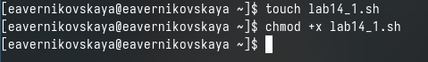

Создание файла lab14_1.sh и добавление прав на исполнение

## Задание №1

Открываю файл lab14_1.sh в текстовом редакторе gedit и пишу командный файл, реализующий упрощённый механизм семафоров (подробнее см. в задании №1) (рис. 2)

## Задание №1

[figure not shown]

Написанная программа для lab14_1.sh

## Задание №1

Далее запускаю файл с помощью bash и проверяю работу командного файла (рис. 3)

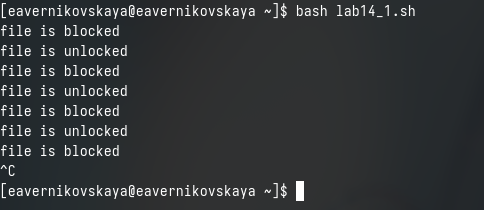

Проверка работы командного файла lab14_1.sh

## Задание №2

Изучаю содержимое каталога /usr/share/man/man1. В нем находятся архивы текстовых файлов, содержащих справку по большинству установленных в системе программ и команд (рис. 4), (рис. 5)

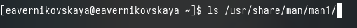

Команда

## Задание №2

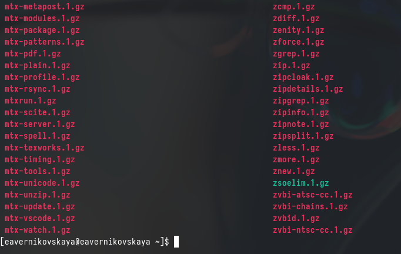

Содержимое каталога /usr/share/man/man1

## Задание №2

Создаю файл для второго задания с расширением sh и делаю его исполняемым (рис. 6)

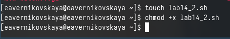

Создание файла lab14_2.sh и добавление прав на исполнение

## Задание №2

Открываю файл lab14_2.sh в текстовом редакторе gedit и пишу командный файл, который будет реализовывать команду man (рис. 7)

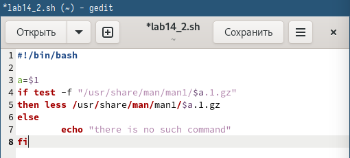

Написанная программа для lab14_2.sh

## Задание №2

Далее запускаю файл с помощью bash и проверяю его работу (рис. 8), (рис. 9), (рис. 10), (рис. 11)

## Задание №2

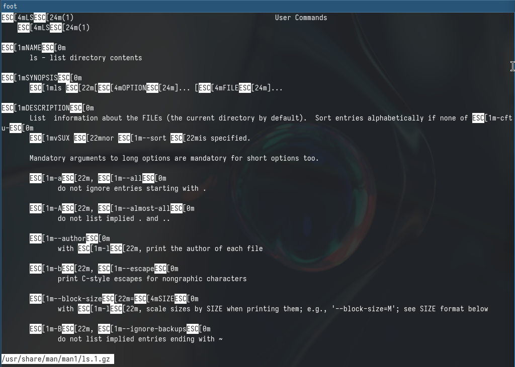

man команды ls (работа командного файла lab14_2.sh)

## Задание №2

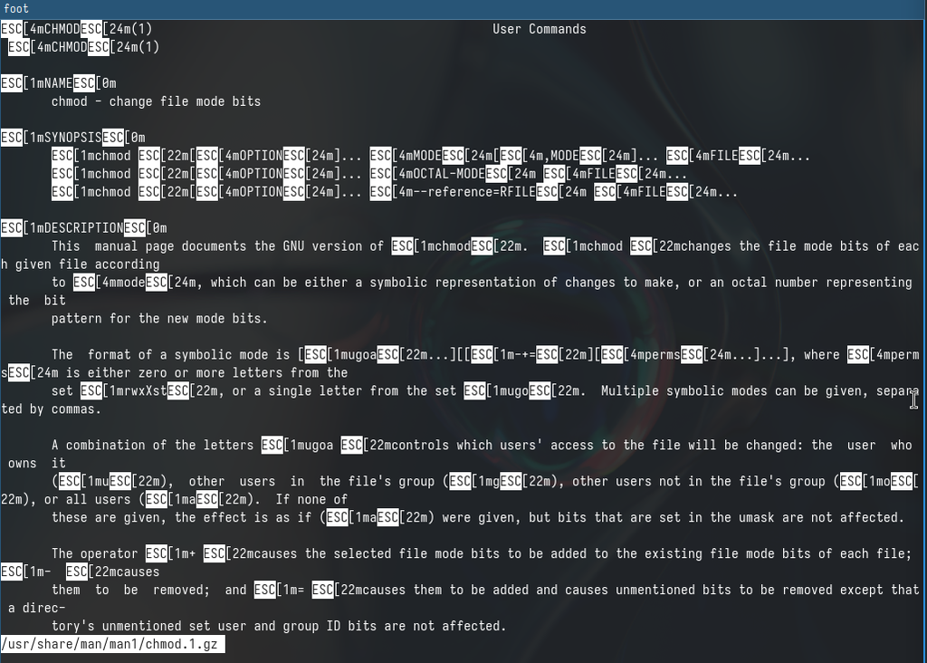

man команды chmod (работа командного файла lab14_2.sh)

## Задание №2

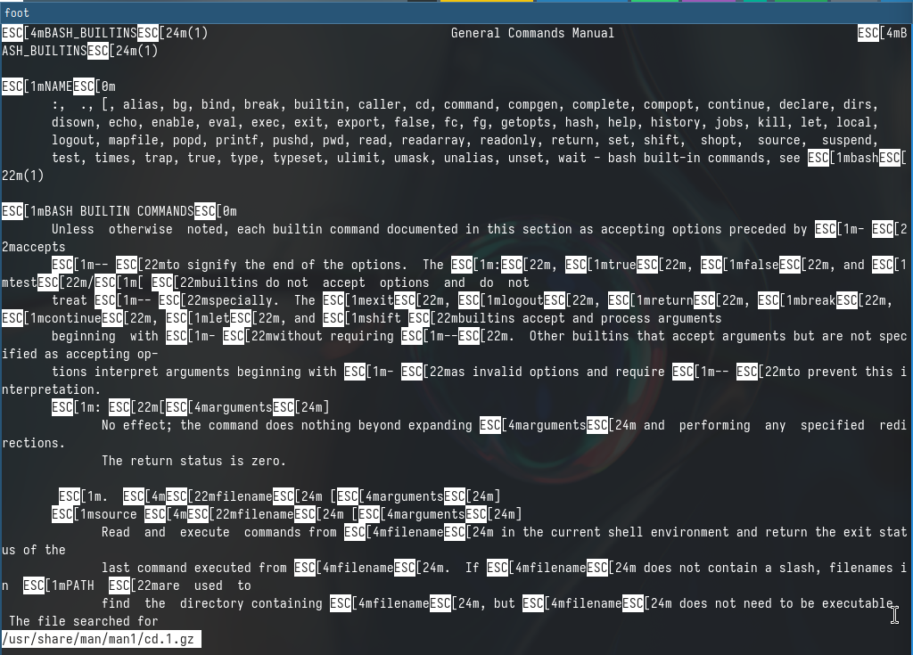

man команды cd (работа командного файла lab14_2.sh)

## Задание №2

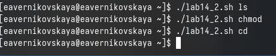

Проверка работы командного файла lab14_2.sh

## Задание №3

Создаю файл для третьего задания с расширением sh и делаю его исполняемым (рис. 12)

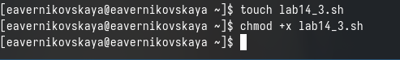

## Задание №3

Открываю файл lab14_3.sh в текстовом редакторе gedit и пишу командный файл, генерирующий случайную последовательность букв латинского алфавита (рис. 13)

## Задание №3

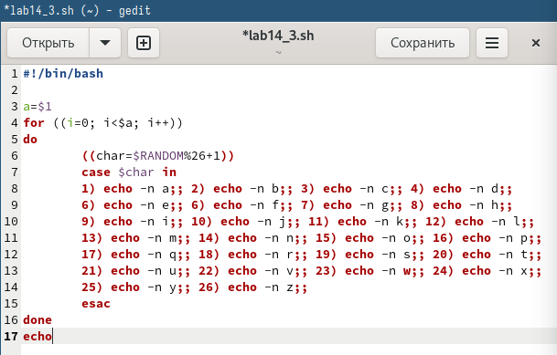

Написанная программа для lab14_3.sh

## Задание №3

Далее запускаю файл с помощью bash и проверяю его работу (рис. 14)

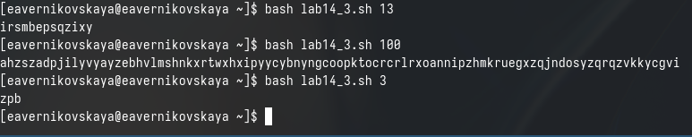

Проверка работы командного файла lab14_3.sh

# Подведение итогов

## Выводы

В ходе выполнения лабораторной работы мы изучили основы программирования в оболочке ОС UNIX а также научились писать более сложные командные файлы с использованием логических управляющих конструкций и циклов.

## Список литературы

Не пользовалась сайтами.